# Quality Assurance Machine Learning Task

### This notebook pre-processes an API output file in CSV format, where each feature consists of dictionary-type values in the form of key-value pairs.

## Purpose of this task

By the end of this task we should be able to perform text processing techniques to call transcripts into Category 6 (Introduction Calls) and Category 7 (Final Loan Details & Next Steps).

```python
# Importing the all necessary libraries
import pandas as pd
import numpy as np
import ast
import random
import tensorflow as tf
import matplotlib.pyplot as plt
from sklearn.model_selection import train_test_split
from sklearn.preprocessing import OneHotEncoder, LabelEncoder, StandardScaler, OrdinalEncoder
from sklearn.ensemble import RandomForestClassifier, GradientBoostingClassifier
from sklearn.tree import DecisionTreeClassifier
from sklearn.model_selection import train_test_split
from sklearn.preprocessing import OneHotEncoder, LabelEncoder, MinMaxScaler, StandardScaler
from sklearn.metrics import classification_report, accuracy_score
from sklearn.metrics import accuracy_score, f1_score, recall_score, precision_score
from tensorflow.keras.layers import Embedding, Flatten, Dense, Input, Dropout, BatchNormalization, GaussianNoise
from tensorflow.keras.models import Model, Sequential
from tensorflow.keras.optimizers import Adam
from tensorflow.keras.callbacks import EarlyStopping
from xgboost import XGBClassifier
```

### Step 1: Load dataset

In this step, we:

1. Load both the labelled and unlabelled csv dataset and display the top 5 rows of both datasets

```python
# Load Labeled & Unlabeled datasets
df_labeled = pd.read_csv("Msc_Project_Data_With_Targets.csv")
df_unlabeled = pd.read_csv("Msc_Project_Data_Without_Targets.csv")
```

```python
# Print the top 5 rows of labelled datasets
df_labeled.head(5)
```

|  | Call_Type_Name | Low_Level_Segment6 | Business_Requirement1 | Business_Requirement2 | Business_Requirement3 | Business_Requirement4 | Business_Requirement5 | Low_Level_Segment1 | Low_Level_Segment2 | Low_Level_Segment3 | Low_Level_Segment4 | Low_Level_Segment5 | Mid_Level_Key_Segment1 | Mid_Level_Segment2 | Mid_Level_Segment3 | Mid_Level_Segment4 | Mid_Level_Segment5 | Mid_Level_Segment6 | Legacy_Segment1 | Legacy_Segment2 |
| --- | --- | --- | --- | --- | --- | --- | --- | --- | --- | --- | --- | --- | --- | --- | --- | --- | --- | --- | --- | --- |
| 0 | Category 1 | {'item1': 'Red', 'item2': 'Red', 'item3': 'Red... | {'item1': True, 'item2': True, 'item3': True, ... | {'item1': False, 'item2': False, 'item3': 'Red'} | {'item1': False} | {'item1': False, 'item2': False, 'item3': Fals... | {'item1': False, 'item2': False, 'item3': Fals... | {'item1': False, 'item2': True, 'item3': False... | {'item1': False, 'item2': False, 'item3': Fals... | {'item1': False, 'item2': False, 'item3': Fals... | {'item1': False, 'item2': False, 'item3': Fals... | {'item1': False, 'item2': False, 'item3': Fals... | {'item1': False, 'item2': False, 'item3': 'Poo... | {'item1': False, 'item2': False, 'item3': Fals... | {'item1': False, 'item2': False, 'item3': Fals... | {'item1': False, 'item2': False, 'item3': Fals... | {'item1': False, 'item2': False, 'item3': Fals... | {'item1': True, 'item2': False, 'item3': False... | {'item1': True, 'item2': True, 'item3': True, ... | {'item1': 'Amber', 'item2': 'Red', 'item3': 'R... |
| 1 | Category 4 | {'item1': 'Red', 'item2': 'Red', 'item3': 'Red... | {'item1': True, 'item2': True, 'item3': True, ... | {'item1': False, 'item2': False, 'item3': 'Red'} | {'item1': False} | {'item1': False, 'item2': False, 'item3': Fals... | {'item1': False, 'item2': False, 'item3': Fals... | {'item1': True, 'item2': False, 'item3': False... | {'item1': False, 'item2': False, 'item3': Fals... | {'item1': False, 'item2': False, 'item3': Fals... | {'item1': False, 'item2': False, 'item3': Fals... | {'item1': False, 'item2': False, 'item3': Fals... | {'item1': False, 'item2': False, 'item3': 'Poo... | {'item1': False, 'item2': False, 'item3': Fals... | {'item1': False, 'item2': False, 'item3': Fals... | {'item1': False, 'item2': False, 'item3': Fals... | {'item1': True, 'item2': True, 'item3': False,... | {'item1': True, 'item2': False, 'item3': True,... | {'item1': True, 'item2': True, 'item3': True, ... | {'item1': 'Green', 'item2': 'Red', 'item3': 'R... |
| 2 | Category 7 | {'item1': 'Red', 'item2': 'Red', 'item3': 'Red... | {'item1': True, 'item2': True, 'item3': True, ... | {'item1': True, 'item2': True, 'item3': 'Green'} | {'item1': True} | {'item1': True, 'item2': True, 'item3': True, ... | {'item1': True, 'item2': True, 'item3': False,... | {'item1': True, 'item2': True, 'item3': False,... | {'item1': True, 'item2': True, 'item3': False,... | {'item1': True, 'item2': False, 'item3': True,... | {'item1': True, 'item2': False, 'item3': True,... | {'item1': True, 'item2': True, 'item3': False,... | {'item1': True, 'item2': False, 'item3': 'Good... | {'item1': False, 'item2': False, 'item3': Fals... | {'item1': False, 'item2': False, 'item3': Fals... | {'item1': False, 'item2': False, 'item3': Fals... | {'item1': False, 'item2': False, 'item3': Fals... | {'item1': False, 'item2': False, 'item3': Fals... | {'item1': True, 'item2': True, 'item3': True, ... | {'item1': 'Amber', 'item2': 'Green', 'item3': ... |
| 3 | Category 7 | {'item1': 'Red', 'item2': 'Green', 'item3': 'R... | {'item1': True, 'item2': True, 'item3': True, ... | {'item1': True, 'item2': True, 'item3': 'Green'} | {'item1': True} | {'item1': True, 'item2': True, 'item3': True, ... | {'item1': True, 'item2': True, 'item3': False,... | {'item1': True, 'item2': True, 'item3': True, ... | {'item1': True, 'item2': True, 'item3': True, ... | {'item1': True, 'item2': True, 'item3': True, ... | {'item1': False, 'item2': False, 'item3': True... | {'item1': True, 'item2': True, 'item3': False,... | {'item1': True, 'item2': True, 'item3': 'Good ... | {'item1': False, 'item2': True, 'item3': False... | {'item1': False, 'item2': False, 'item3': Fals... | {'item1': False, 'item2': False, 'item3': Fals... | {'item1': False, 'item2': True, 'item3': False... | {'item1': True, 'item2': False, 'item3': False... | {'item1': True, 'item2': True, 'item3': True, ... | {'item1': 'Green', 'item2': 'Green', 'item3': ... |
| 4 | Category 7 | {'item1': 'Red', 'item2': 'Red', 'item3': 'Gre... | {'item1': True, 'item2': True, 'item3': True, ... | {'item1': True, 'item2': True, 'item3': 'Green'} | {'item1': True} | {'item1': True, 'item2': True, 'item3': True, ... | {'item1': True, 'item2': True, 'item3': False,... | {'item1': True, 'item2': True, 'item3': True, ... | {'item1': True, 'item2': True, 'item3': True, ... | {'item1': True, 'item2': False, 'item3': True,... | {'item1': False, 'item2': False, 'item3': Fals... | {'item1': False, 'item2': False, 'item3': Fals... | {'item1': True, 'item2': True, 'item3': 'Good ... | {'item1': False, 'item2': False, 'item3': Fals... | {'item1': False, 'item2': False, 'item3': Fals... | {'item1': False, 'item2': False, 'item3': Fals... | {'item1': False, 'item2': False, 'item3': Fals... | {'item1': False, 'item2': False, 'item3': Fals... | {'item1': True, 'item2': True, 'item3': True, ... | {'item1': 'Green', 'item2': 'Green', 'item3': ... |

```python
# Print the top 5 rows of unlabeled datasets
df_unlabeled.head(5)
```

|  | Low_Level_Segment6 | Business_Requirement1 | Business_Requirement2 | Business_Requirement3 | Business_Requirement4 | Business_Requirement5 | Low_Level_Segment1 | Low_Level_Segment2 | Low_Level_Segment3 | Low_Level_Segment4 | Low_Level_Segment5 | Mid_Level_Key_Segment1 | Mid_Level_Segment2 | Mid_Level_Segment3 | Mid_Level_Segment4 | Mid_Level_Segment5 | Mid_Level_Segment6 | Legacy_Segment1 | Legacy_Segment2 |
| --- | --- | --- | --- | --- | --- | --- | --- | --- | --- | --- | --- | --- | --- | --- | --- | --- | --- | --- | --- |
| 0 | {'item1': 'Red', 'item2': 'Red', 'item3': 'Red... | {'item1': False, 'item2': False, 'item3': Fals... | {'item1': False, 'item2': False, 'item3': 'Red'} | {'item1': False} | {'item1': False, 'item2': False, 'item3': Fals... | {'item1': False, 'item2': False, 'item3': Fals... | {'item1': False, 'item2': False, 'item3': Fals... | {'item1': False, 'item2': False, 'item3': Fals... | {'item1': False, 'item2': False, 'item3': Fals... | {'item1': False, 'item2': False, 'item3': Fals... | {'item1': False, 'item2': False, 'item3': Fals... | {'item1': False, 'item2': False, 'item3': 'Poo... | {'item1': False, 'item2': False, 'item3': Fals... | {'item1': False, 'item2': False, 'item3': Fals... | {'item1': False, 'item2': False, 'item3': Fals... | {'item1': False, 'item2': False, 'item3': Fals... | {'item1': False, 'item2': False, 'item3': Fals... | {'item1': False, 'item2': False, 'item3': Fals... | {'item1': 'Red', 'item2': 'Red', 'item3': 'Red... |
| 1 | {'item1': 'Red', 'item2': 'Red', 'item3': 'Red... | {'item1': False, 'item2': False, 'item3': Fals... | {'item1': False, 'item2': False, 'item3': 'Red'} | {'item1': False} | {'item1': False, 'item2': False, 'item3': Fals... | {'item1': False, 'item2': False, 'item3': Fals... | {'item1': False, 'item2': True, 'item3': False... | {'item1': False, 'item2': False, 'item3': Fals... | {'item1': False, 'item2': False, 'item3': Fals... | {'item1': False, 'item2': False, 'item3': Fals... | {'item1': False, 'item2': False, 'item3': Fals... | {'item1': False, 'item2': False, 'item3': 'Poo... | {'item1': False, 'item2': False, 'item3': Fals... | {'item1': False, 'item2': False, 'item3': Fals... | {'item1': False, 'item2': False, 'item3': Fals... | {'item1': False, 'item2': False, 'item3': Fals... | {'item1': False, 'item2': False, 'item3': Fals... | {'item1': False, 'item2': False, 'item3': Fals... | {'item1': 'Red', 'item2': 'Red', 'item3': 'Red... |
| 2 | {'item1': 'Red', 'item2': 'Red', 'item3': 'Red... | {'item1': True, 'item2': True, 'item3': True, ... | {'item1': True, 'item2': True, 'item3': 'Green'} | {'item1': False} | {'item1': False, 'item2': False, 'item3': Fals... | {'item1': False, 'item2': False, 'item3': Fals... | {'item1': False, 'item2': True, 'item3': False... | {'item1': False, 'item2': False, 'item3': Fals... | {'item1': False, 'item2': False, 'item3': Fals... | {'item1': False, 'item2': False, 'item3': Fals... | {'item1': False, 'item2': False, 'item3': Fals... | {'item1': False, 'item2': False, 'item3': 'Poo... | {'item1': False, 'item2': False, 'item3': Fals... | {'item1': False, 'item2': False, 'item3': Fals... | {'item1': False, 'item2': False, 'item3': Fals... | {'item1': False, 'item2': False, 'item3': Fals... | {'item1': False, 'item2': False, 'item3': Fals... | {'item1': True, 'item2': True, 'item3': True, ... | {'item1': 'Green', 'item2': 'Red', 'item3': 'G... |
| 3 | {'item1': 'Red', 'item2': 'Red', 'item3': 'Red... | {'item1': False, 'item2': False, 'item3': Fals... | {'item1': False, 'item2': False, 'item3': 'Red'} | {'item1': False} | {'item1': False, 'item2': False, 'item3': Fals... | {'item1': False, 'item2': False, 'item3': Fals... | {'item1': False, 'item2': False, 'item3': Fals... | {'item1': False, 'item2': False, 'item3': Fals... | {'item1': False, 'item2': False, 'item3': Fals... | {'item1': False, 'item2': False, 'item3': Fals... | {'item1': False, 'item2': False, 'item3': Fals... | {'item1': False, 'item2': False, 'item3': 'Poo... | {'item1': False, 'item2': False, 'item3': Fals... | {'item1': False, 'item2': False, 'item3': Fals... | {'item1': False, 'item2': False, 'item3': Fals... | {'item1': False, 'item2': False, 'item3': Fals... | {'item1': False, 'item2': False, 'item3': Fals... | {'item1': False, 'item2': False, 'item3': Fals... | {'item1': 'Red', 'item2': 'Red', 'item3': 'Red... |
| 4 | {'item1': 'Red', 'item2': 'Red', 'item3': 'Red... | {'item1': False, 'item2': False, 'item3': Fals... | {'item1': False, 'item2': False, 'item3': 'Red'} | {'item1': False} | {'item1': False, 'item2': False, 'item3': Fals... | {'item1': False, 'item2': False, 'item3': Fals... | {'item1': False, 'item2': True, 'item3': False... | {'item1': False, 'item2': False, 'item3': Fals... | {'item1': False, 'item2': False, 'item3': Fals... | {'item1': False, 'item2': False, 'item3': Fals... | {'item1': False, 'item2': False, 'item3': Fals... | {'item1': False, 'item2': False, 'item3': 'Poo... | {'item1': False, 'item2': False, 'item3': Fals... | {'item1': False, 'item2': False, 'item3': Fals... | {'item1': False, 'item2': False, 'item3': Fals... | {'item1': False, 'item2': False, 'item3': Fals... | {'item1': False, 'item2': False, 'item3': Fals... | {'item1': False, 'item2': False, 'item3': Fals... | {'item1': 'Red', 'item2': 'Red', 'item3': 'Red... |

#### This function "dictionary_to_text" converts a dictionary-like string nto a text format where key-value pairs are joined together with an underscore (_) and separated by commas.

**Input data:** {'item1': 'Red', 'item2': 'Red', 'item3': 'Red', 'item4': 'Red', 'item5': 'Red', 'item6': 'uncategorized'}

**Output data:** 'item1_Red', 'item2_Red', 'item3_Red', 'item4_Red', 'item5_Red', 'item6_uncategorized'

The .map() function applies the dictionary_to_text function on each element on the dataset

```python
# Function to Convert Dictionary-Like Strings to Text
def dictionary_to_text(data):
    if isinstance(data, str) and data.startswith("{"):
        try:
            parsed_data = ast.literal_eval(data)
            if isinstance(parsed_data, dict):
                return ', '.join([f"{key}_{value}" for key, value in parsed_data.items() if value is not None])
        except (ValueError, SyntaxError):
            pass
    return data

# Apply Transformation
df_labeled = df_labeled.map(dictionary_to_text)
df_unlabeled = df_unlabeled.map(dictionary_to_text)
```

### Handling the categorical Columns

##### 1. The mapping is stored in category_mappings, allowing it to be applied to other datasets (e.g., df_unlabeled).

##### 2. The mapping is stored in category_mappings, allowing it to be applied to other datasets (e.g., df_unlabeled).

##### 3. Avoids High-Dimensionality: One-hot encoding for high-cardinality features creates too many columns.

##### 4. This method keeps a single column with numeric values.

##### 5. Handles Unseen Data Gracefully: Any unseen category gets -1, preventing errors when applying the same transformation to new data.

```python
# Identify Categorical Columns
categorical_cols = df_labeled.select_dtypes(include=['object']).columns.tolist()
high_cardinality_cols = [col for col in categorical_cols if df_labeled[col].nunique() >= 30]
low_cardinality_cols = [col for col in categorical_cols if df_labeled[col].nunique() < 30 and col != "Call_Type_Name"]

# One-Hot Encode Low-Cardinality Categorical Features
encoder = OneHotEncoder(handle_unknown='ignore', sparse_output=False)
encoded_low_cardinality = encoder.fit_transform(df_labeled[low_cardinality_cols])
encoded_low_cardinality_df = pd.DataFrame(encoded_low_cardinality, columns=encoder.get_feature_names_out(low_cardinality_cols))

# Label Encode Target Variable
label_encoder = LabelEncoder()
df_labeled["Call_Type_Name"] = label_encoder.fit_transform(df_labeled["Call_Type_Name"])
num_classes = len(label_encoder.classes_)

# Map High-Cardinality Features Consistently
category_mappings = {}
for col in high_cardinality_cols:
    unique_values = df_labeled[col].astype("category").cat.categories
    category_mappings[col] = {val: idx for idx, val in enumerate(unique_values)}
    df_labeled[col] = df_labeled[col].map(category_mappings[col]).fillna(-1).astype(int)
```

```python
# Apply Same Encoding to Unlabeled Data
for col in high_cardinality_cols:
    df_unlabeled[col] = df_unlabeled[col].map(category_mappings[col]).fillna(-1).astype(int)

encoded_low_cardinality_unlabeled = encoder.transform(df_unlabeled[low_cardinality_cols])
encoded_low_cardinality_unlabeled_df = pd.DataFrame(encoded_low_cardinality_unlabeled,
                                                    columns=encoder.get_feature_names_out(low_cardinality_cols))

# Combine Features for Both Datasets
X_labeled = np.hstack((df_labeled[high_cardinality_cols].values, encoded_low_cardinality))
X_unlabeled = np.hstack((df_unlabeled[high_cardinality_cols].values, encoded_low_cardinality_unlabeled))

scaler = StandardScaler()
```

# <============ Supervised Learning Approach ============>

##### Feature scaling which ensures that all numerical features in the dataset have the same scale

```
- fit(X_labeled): Computes the mean and standard deviation (if using StandardScaler) or min/max values (if using MinMaxScaler).
- transform(X_labeled): Applies the scaling transformation to standardize the data.
```

```python
X_scaled = scaler.fit_transform(X_labeled)
```

```python
# Splitting the dataset
X_train, X_test, y_train, y_test = train_test_split(X_scaled, df_labeled["Call_Type_Name"], test_size=0.2, random_state=42)
```

#### This code is performing classification model training and evaluation using three different machine learning models stored in a dictionary formate

```
- Random Forest Classifier
- Decision Tree Classifier
- Gradient Boosting Classifier
```

```python
# Initialize the models
models = {
    "Random Forest": RandomForestClassifier(n_estimators=100, random_state=42),
    "Decision Tree": DecisionTreeClassifier(random_state=42),
    "Gradient Boosting": GradientBoostingClassifier(n_estimators=100, random_state=42)
}
```

```python
# Loops through each model, trains it using the training data (X_train, y_train).
results = {}

for name, model in models.items():
    # Fit the model
    model.fit(X_train, y_train)

    # Predict on the training set
    y_train_pred = model.predict(X_train)
    train_accuracy = accuracy_score(y_train, y_train_pred)
    train_f1 = f1_score(y_train, y_train_pred, average='weighted')
    train_recall = recall_score(y_train, y_train_pred, average='weighted')
    train_precision = precision_score(y_train, y_train_pred, average='weighted')

    # Predict on the test set
    y_test_pred = model.predict(X_test)
    test_accuracy = accuracy_score(y_test, y_test_pred)
    test_f1 = f1_score(y_test, y_test_pred, average='weighted')
    test_recall = recall_score(y_test, y_test_pred, average='weighted')
    test_precision = precision_score(y_test, y_test_pred, average='weighted')

    # Store all the metrics in the results dictionary
    results[name] = {
        "Train Accuracy": train_accuracy,
        "Train F1-Score": train_f1,
        "Train Recall": train_recall,
        "Train Precision": train_precision,
        "Test Accuracy": test_accuracy,
        "Test F1-Score": test_f1,
        "Test Recall": test_recall,
        "Test Precision": test_precision
    }
```

```python
# Print out the results
for name, metrics in results.items():
    print(f"🔹{name} Model Metrics:")
    for metric, value in metrics.items():
        print(f"  {metric}: {value:.4f}")
    print()
```

```
🔹Random Forest Model Metrics:
  Train Accuracy: 0.9969
  Train F1-Score: 0.9968
  Train Recall: 0.9969
  Train Precision: 0.9969
  Test Accuracy: 0.9625
  Test F1-Score: 0.9560
  Test Recall: 0.9625
  Test Precision: 0.9508

🔹Decision Tree Model Metrics:
  Train Accuracy: 0.9969
  Train F1-Score: 0.9970
  Train Recall: 0.9969
  Train Precision: 0.9972
  Test Accuracy: 0.9250
  Test F1-Score: 0.9349
  Test Recall: 0.9250
  Test Precision: 0.9490

🔹Gradient Boosting Model Metrics:
  Train Accuracy: 0.9969
  Train F1-Score: 0.9970
  Train Recall: 0.9969
  Train Precision: 0.9972
  Test Accuracy: 0.9500
  Test F1-Score: 0.9548
  Test Recall: 0.9500
  Test Precision: 0.9636
```

#### Making a prediction on the labeled data to verify the prediction is correct (Random Forest)

```python
X_labeled_scaled = scaler.fit_transform(X_labeled)
X_unlabeled_scaled = scaler.transform(X_unlabeled)
```

```python
# Preprocessed feature matrix
X_train, X_test, y_train, y_test = train_test_split(X_labeled_scaled, df_labeled["Call_Type_Name"], test_size=0.2, random_state=42)

# Training the Random Forest Model with 200 trees
rf_model = RandomForestClassifier(n_estimators=200, random_state=42)
rf_model.fit(X_train, y_train)

# Predictions (y_test_pred) are made on X_test.
y_test_pred = rf_model.predict(X_test)

# Performance Metrics Calculation which includes Accuracy, F1-score, Recall and Precision
test_accuracy = accuracy_score(y_test, y_test_pred)
test_f1 = f1_score(y_test, y_test_pred, average='weighted')
test_recall = recall_score(y_test, y_test_pred, average='weighted')
test_precision = precision_score(y_test, y_test_pred, average='weighted')

# The performance metrics are printed in a readable format.
print("\nModel Performance on Test Set:")
print(f"🔹 Test Accuracy: {test_accuracy:.4f}")
print(f"🔹 Test F1-Score: {test_f1:.4f}")
print(f"🔹 Test Recall: {test_recall:.4f}")
print(f"🔹 Test Precision: {test_precision:.4f}")


# The model predicts labels for the full dataset
y_labeled_pred = rf_model.predict(X_labeled_scaled)

#The predictions are converted back to human-readable class names using label_encoder.inverse_transform()
y_labeled_pred_labels = label_encoder.inverse_transform(y_labeled_pred)

df_labeled["Predicted_Call_Type_Name"] = y_labeled_pred_labels
df_labeled["Actual_Call_Type_Name"] = label_encoder.inverse_transform(df_labeled["Call_Type_Name"])

# Comparing Actual vs. Predicted Labels
print("\n Sample Predictions vs Actual:")
print(df_labeled[["Actual_Call_Type_Name", "Predicted_Call_Type_Name"]].head(20))

# Calculating Overall Accuracy on Labeled Data
correct_predictions = (df_labeled["Actual_Call_Type_Name"] == df_labeled["Predicted_Call_Type_Name"]).sum()
total_samples = len(df_labeled)
correct_percentage = (correct_predictions / total_samples) * 100

print(f"\n✅ Correctly Predicted Labels: {correct_predictions}/{total_samples} ({correct_percentage:.2f}%)")

# Final Classification Report
print("\n Classification Report for Labeled Data:")
print(classification_report(df_labeled["Call_Type_Name"], y_labeled_pred))
```

```
Model Performance on Test Set:
🔹 Test Accuracy: 0.9625
🔹 Test F1-Score: 0.9560
🔹 Test Recall: 0.9625
🔹 Test Precision: 0.9508

 Sample Predictions vs Actual:
   Actual_Call_Type_Name Predicted_Call_Type_Name
0             Category 1               Category 1
1             Category 4               Category 4
2             Category 7               Category 7
3             Category 7               Category 7
4             Category 7               Category 7
5             Category 7               Category 7
6             Category 7               Category 7
7             Category 7               Category 7
8             Category 7               Category 7
9             Category 6               Category 6
10            Category 7               Category 7
11            Category 7               Category 7
12            Category 7               Category 7
13            Category 1               Category 1
14            Category 7               Category 7
15            Category 7               Category 7
16            Category 7               Category 7
17            Category 7               Category 7
18            Category 7               Category 7
19            Category 7               Category 7

✅ Correctly Predicted Labels: 396/400 (99.00%)

 Classification Report for Labeled Data:
              precision    recall  f1-score   support

           0       1.00      0.97      0.98        29
           1       1.00      1.00      1.00         6
           2       1.00      0.94      0.97        16
           3       1.00      1.00      1.00         1
           4       0.89      1.00      0.94         8
           5       0.98      0.98      0.98        59
           6       0.99      1.00      0.99       281

    accuracy                           0.99       400
   macro avg       0.98      0.98      0.98       400
weighted avg       0.99      0.99      0.99       400
```

#### This bar chart visually compares Recall and F1-Score for two specific categories 6 and 7 in our classification model.

Both Recall (blue bars) and F1-score (gray bars) appear to be very close to 1.0, indicating that the model is performing very well in identifying these categories.

##### Key takeaway: The model achieves high recall and F1-score, meaning it correctly identifies most instances of these categories with minimal misclassification.

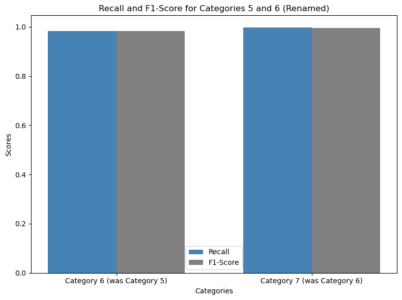

```python
import matplotlib.pyplot as plt
import numpy as np
from sklearn.metrics import classification_report

# Sample classification report output (from your previous code)
classification_report_output = classification_report(df_labeled["Call_Type_Name"], y_labeled_pred, output_dict=True)

# Extract Recall and F1-score for Category 5 (which will be labeled as Category 6) and Category 6 (which will be labeled as Category 7)
recall_category_5 = classification_report_output['5']['recall']
f1_category_5 = classification_report_output['5']['f1-score']

recall_category_6 = classification_report_output['6']['recall']
f1_category_6 = classification_report_output['6']['f1-score']

# Categories for the plot (renaming as required)
categories = ['Category 6 (was Category 5)', 'Category 7 (was Category 6)']

# Recall and F1 scores
recall_scores = [recall_category_5, recall_category_6]
f1_scores = [f1_category_5, f1_category_6]

# Plot
fig, ax = plt.subplots(figsize=(8, 6))

# Bar positions for recall and F1
x = np.arange(len(categories))  # The category labels
width = 0.35  # Width of the bars

# Plotting recall and F1 scores
bars_recall = ax.bar(x - width/2, recall_scores, width, label='Recall', color='steelblue')
bars_f1 = ax.bar(x + width/2, f1_scores, width, label='F1-Score', color='grey')

# Labels and title
ax.set_xlabel('Categories')
ax.set_ylabel('Scores')
ax.set_title('Recall and F1-Score for Categories 5 and 6 (Renamed)')
ax.set_xticks(x)
ax.set_xticklabels(categories)
ax.legend()

# Show the plot
plt.tight_layout()
plt.show()
```

### Save the predictions on unlabeled data

```python
# Predict on Unlabeled Data
y_unlabeled_pred = rf_model.predict(X_unlabeled_scaled)
y_unlabeled_pred_labels = label_encoder.inverse_transform(y_unlabeled_pred)

# Save Predictions
df_unlabeled["Predicted_Call_Type_Name"] = y_unlabeled_pred_labels
df_unlabeled.to_csv("Supervised_Msc_Project_Predicted_Outputs.csv", index=False)

print("'Supervised_Msc_Project_Predicted_Outputs.csv'")

# Validate Model on Labeled Data for Checking Prediction Accuracy
y_labeled_pred = rf_model.predict(X_labeled_scaled)
y_labeled_pred_labels = label_encoder.inverse_transform(y_labeled_pred)

df_labeled["Predicted_Call_Type_Name"] = y_labeled_pred_labels

# Compare Predictions with Actual Values
correct_predictions = (df_labeled["Call_Type_Name"] == y_labeled_pred).sum()
total_samples = len(df_labeled)
correct_percentage = (correct_predictions / total_samples) * 100

print(f"\n✅ Correctly Predicted Labels: {correct_predictions}/{total_samples} ({correct_percentage:.2f}%)")
print("\n🔹 Classification Report for Labeled Data:")
print(classification_report(df_labeled["Call_Type_Name"], y_labeled_pred))

#Save Validation Results
df_labeled.to_csv("🔹 Supervised_Msc_Project_Labeled_Validation.csv", index=False)
print("\n🔹 Labeled Data Predictions Saved in 'Supervised_Msc_Project_Labeled_Validation.csv'")
```

```
'Supervised_Msc_Project_Predicted_Outputs.csv'

✅ Correctly Predicted Labels: 396/400 (99.00%)

🔹 Classification Report for Labeled Data:
              precision    recall  f1-score   support

           0       1.00      0.97      0.98        29
           1       1.00      1.00      1.00         6
           2       1.00      0.94      0.97        16
           3       1.00      1.00      1.00         1
           4       0.89      1.00      0.94         8
           5       0.98      0.98      0.98        59
           6       0.99      1.00      0.99       281

    accuracy                           0.99       400
   macro avg       0.98      0.98      0.98       400
weighted avg       0.99      0.99      0.99       400


🔹 Labeled Data Predictions Saved in 'Supervised_Msc_Project_Labeled_Validation.csv'
```

#### Model Accuracy Comparison

```
- This bar chart compares the training and test accuracy for three models:
    -Random Forest
    -Decision Tree
    -Gradient Boosting
- Training accuracy (blue bars) is at 100% for all models, while test accuracy (gray bars) is slightly lower:
    -Random Forest: 96%
    -Decision Tree: 93%
    -Gradient Boosting: 95%
```

##### Random Forest performs best on test data (96%), while Decision Tree is the lowest (93%).

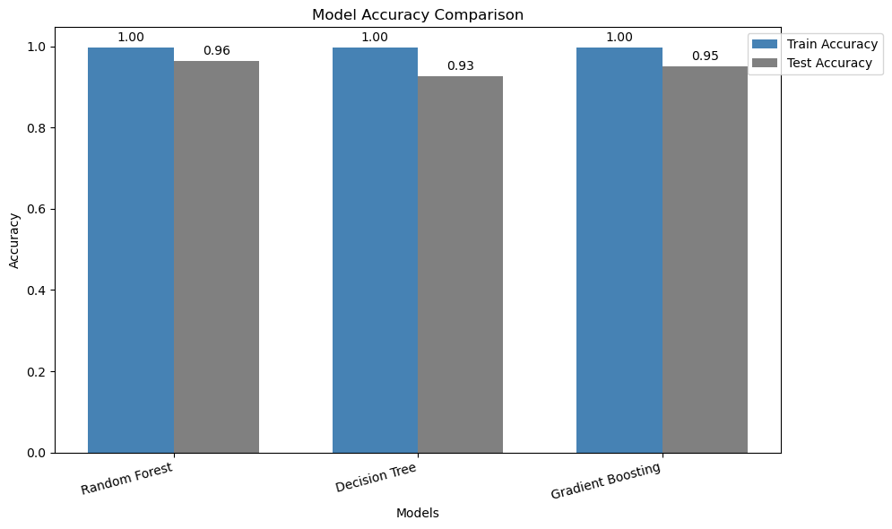

```python
# Create a bar chart for accuracies
models_names = list(results.keys())
train_accuracies = [results[name]["Train Accuracy"] for name in models_names]
test_accuracies = [results[name]["Test Accuracy"] for name in models_names]

x = np.arange(len(models_names))  # Label locations
width = 0.35  # Bar width


fig, ax = plt.subplots(figsize=(10, 6))
rects1 = ax.bar(x - width/2, train_accuracies, width, label='Train Accuracy', color='steelblue')
rects2 = ax.bar(x + width/2, test_accuracies, width, label='Test Accuracy', color='grey')

# Labels and formatting
ax.set_xlabel('Models')
ax.set_ylabel('Accuracy')
ax.set_title('Model Accuracy Comparison')
ax.set_xticks(x)
ax.set_xticklabels(models_names, rotation=15, ha='right')

# Move legend to top-right without overlapping bars (stacked vertically)
ax.legend(loc='upper right', bbox_to_anchor=(1.15, 1))

# Add value labels to bars
def add_labels(rects):
    for rect in rects:
        height = rect.get_height()
        ax.annotate(f'{height:.2f}',
                    xy=(rect.get_x() + rect.get_width() / 2, height),
                    xytext=(0, 3),
                    textcoords='offset points',
                    ha='center', va='bottom')

add_labels(rects1)
add_labels(rects2)

plt.tight_layout()
plt.show()
```

#### F1-Score & Recall for Category 6 & 7 (Training vs Test Data)

```
- Left chart: F1-score and Recall for Training Data.
- Right chart: F1-score and Recall for Test Data.
- Both categories (Category 6 and 7) have high recall and F1-scores in both training and test data.
- Key takeaway: The model performs consistently well across training and test datasets, meaning it's likely generalizing well.
```

##### High performance across all metrics, with Recall and F1-score close to 1.0. and Well-balanced performance across training and test datasets

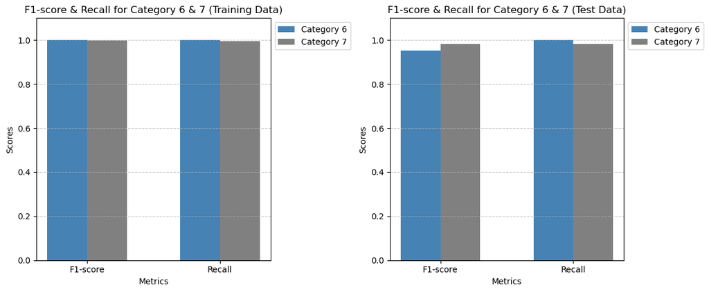

```python
import matplotlib.pyplot as plt
import numpy as np
from sklearn.metrics import classification_report

# Generate classification report as a dictionary for training data
report_train = classification_report(y_train, y_train_pred, output_dict=True)

# Extract F1-score and Recall dynamically for classes 5 & 6 from training data
class_labels = ["5", "6"]
metrics = ["f1-score", "recall"]

data_train = {label: [report_train[label][metric] for metric in metrics] for label in class_labels}

# Generate classification report as a dictionary for test data
report_test = classification_report(y_test, y_test_pred, output_dict=True)

# Extract F1-score and Recall dynamically for classes 5 & 6 from test data
data_test = {label: [report_test[label][metric] for metric in metrics] for label in class_labels}

# Convert to NumPy arrays for plotting
labels = ["F1-score", "Recall"]

category_6_values_train = np.array(data_train["5"])  # Class 5 -> Category 6 (Train)
category_7_values_train = np.array(data_train["6"])  # Class 6 -> Category 7 (Train)

category_6_values_test = np.array(data_test["5"])  # Class 5 -> Category 6 (Test)
category_7_values_test = np.array(data_test["6"])  # Class 6 -> Category 7 (Test)

x = np.arange(len(labels))  # Label locations
width = 0.3  # Bar width

# Create subplots
fig, (ax1, ax2) = plt.subplots(1, 2, figsize=(12, 5))

# Plot for Training Data
ax1.bar(x - width / 2, category_6_values_train, width, label="Category 6", color="steelblue")
ax1.bar(x + width / 2, category_7_values_train, width, label="Category 7", color="grey")
ax1.set_xlabel("Metrics")
ax1.set_ylabel("Scores")
ax1.set_title("F1-score & Recall for Category 6 & 7 (Training Data)")
ax1.set_xticks(x)
ax1.set_xticklabels(labels)
ax1.legend(loc="upper left", bbox_to_anchor=(1, 1))
ax1.set_ylim(0, 1.1)
ax1.grid(axis="y", linestyle="--", alpha=0.7)

# Plot for Test Data
ax2.bar(x - width / 2, category_6_values_test, width, label="Category 6", color="steelblue")
ax2.bar(x + width / 2, category_7_values_test, width, label="Category 7", color="grey")
ax2.set_xlabel("Metrics")
ax2.set_ylabel("Scores")
ax2.set_title("F1-score & Recall for Category 6 & 7 (Test Data)")
ax2.set_xticks(x)
ax2.set_xticklabels(labels)
ax2.legend(loc="upper left", bbox_to_anchor=(1, 1))
ax2.set_ylim(0, 1.1)
ax2.grid(axis="y", linestyle="--", alpha=0.7)

# Adjust layout to avoid overlap
plt.tight_layout()

# Show the plot
plt.show()
```

## <========== Semi Supervised Learning Approach ==========>

#### This section normalizes the features in both the labeled (X_labeled) and unlabeled (X_unlabeled) datasets using StandardScaler from sklearn.preprocessing

Standardization ensures that all features have a mean of 0 and a standard deviation of 1, which is useful for many machine learning algorithms, especially those that rely on distance-based calculations

##### Example

| Feature 1 | Feature 2 | Feature 3 |
| --- | --- | --- |
| 100 | 50 | 500 |
| 200 | 60 | 700 |
| 300 | 55 | 600 |
| 400 | 70 | 800 |

Step 1: Compute Mean and Standard Deviation For each feature:

Step 2: Apply Standardization Formula $$ X_{\text{scaled}} = \frac{X - \mu}{\sigma} $$

| Feature 1 | Feature 2 | Feature 3 |
| --- | --- | --- |
| -1.16 | -1.23 | -1.16 |
| -0.39 | 0.18 | 0.39 |
| 0.39 | -0.53 | -0.39 |
| 1.16 | 1.58 | 1.16 |

##### Now, all features are centered around 0 with a standard deviation of 1.

```python
# Normalize Features
scaler = StandardScaler()
X_all = np.vstack((X_labeled, X_unlabeled))
X_all_scaled = scaler.fit_transform(X_all)
```

```python
# Split Data Back
X_labeled_scaled = X_all_scaled[:len(X_labeled)]
X_unlabeled_scaled = X_all_scaled[len(X_labeled):]

# Split Labeled Data for Training
X_train, X_test, y_train, y_test = train_test_split(X_labeled_scaled, df_labeled["Call_Type_Name"], test_size=0.2, random_state=42)
```

### Building an Autoencoder for Feature Learning

#### Define the Autoencoder Structure

```
- input_dim: The number of features in the dataset.
- encoding_dim = 64: The bottleneck layer size, meaning the data will be compressed into 64-dimensional representations.
- Input(shape=(input_dim,)): Defines the input layer matching the feature size.
- GaussianNoise(0.1)(input_layer): Adds noise for robustness, helping the model generalize.
- Dense(256, activation='relu', kernel_regularizer='l2'): First dense layer with L2 regularization to prevent overfitting.
- BatchNormalization(): Normalizes activations, speeding up training.
- Dropout(0.6): Drops 60% of neurons randomly to prevent overfitting.
- Dense(128, activation='relu', kernel_regularizer='l2'): Second layer with the same setup.
- encoded = Dense(encoding_dim, activation='relu'): Final encoded (compressed) representation.
```

#### Define Decoder (Mirrors the encoder but in reverse)

```
- Final layer (sigmoid): Outputs values between 0 and 1 to reconstruct the original input.
```

#### Compile the Autoencoder

```
- Creates the autoencoder model using the input layer and the reconstructed output (decoded).
- Adam optimizer with learning rate 0.0003: Balances fast learning with stability.
- Loss function: Mean Squared Error (MSE) is used to minimize reconstruction error.
```

#### Add Early Stopping

```
- early_stopping = EarlyStopping(monitor="loss", patience=5, restore_best_weights=True)
```

#### Train the Autoencoder

```
- Trains the autoencoder on the unlabeled dataset (X_unlabeled_scaled).
- Epochs = 50: The maximum number of training cycles.
- Batch size = 32: Trains in mini-batches of 32 for efficiency.
- Autoencoder learns to reconstruct X_unlabeled_scaled, extracting useful feature representations
```

#### Save the Autoencoder

```
- autoencoder.save("autoencoder_model.h5")
```

#### Extract Encoded Features for Training

```
- encoder_model = Model(input_layer, encoded)
- X_train_encoded = encoder_model.predict(X_train)
- X_test_encoded = encoder_model.predict(X_test)
- X_unlabeled_encoded = encoder_model.predict(X_unlabeled_scaled)
```

### Importance of Autoencoder

```
- Feature Compression – Reduces data dimensionality from input_dim to encoding_dim = 64.
- Noise Reduction – Learns meaningful representations while ignoring noise.
- Improved Model Performance – Encoded features can boost classification accuracy.
- Unsupervised Pretraining – Can be used before training a classifier.
```

```python
# Define Autoencoder
input_dim = X_all.shape[1]
encoding_dim = 64  # Reduced size for efficiency

input_layer = Input(shape=(input_dim,))
x = GaussianNoise(0.1)(input_layer)
x = Dense(256, activation='relu', kernel_regularizer='l2')(x)
x = BatchNormalization()(x)
x = Dropout(0.6)(x)
x = Dense(128, activation='relu', kernel_regularizer='l2')(x)
x = BatchNormalization()(x)
x = Dropout(0.6)(x)
encoded = Dense(encoding_dim, activation='relu')(x)

decoder_x = Dense(128, activation='relu')(encoded)
decoder_x = BatchNormalization()(decoder_x)
decoder_x = Dropout(0.6)(decoder_x)
decoder_x = Dense(256, activation='relu')(decoder_x)
decoder_x = BatchNormalization()(decoder_x)
decoder_x = Dropout(0.6)(decoder_x)
decoded = Dense(input_dim, activation='sigmoid')(decoder_x)

# Compile Autoencoder
autoencoder = Model(input_layer, decoded)
autoencoder.compile(optimizer=Adam(learning_rate=0.0003), loss='mse')

# Early Stopping Callback
early_stopping = EarlyStopping(monitor="loss", patience=5, restore_best_weights=True)

# Train Autoencoder
autoencoder.fit(X_unlabeled_scaled, X_unlabeled_scaled, epochs=50, batch_size=32, verbose=1, callbacks=[early_stopping])

# Save Autoencoder
autoencoder.save("autoencoder_model.h5")

# Extract Encoded Features
encoder_model = Model(input_layer, encoded)
X_train_encoded = encoder_model.predict(X_train)
X_test_encoded = encoder_model.predict(X_test)
X_unlabeled_encoded = encoder_model.predict(X_unlabeled_scaled)
```

[output not shown]

```
WARNING:absl:You are saving your model as an HDF5 file via `model.save()` or `keras.saving.save_model(model)`. This file format is considered legacy. We recommend using instead the native Keras format, e.g. `model.save('my_model.keras')` or `keras.saving.save_model(model, 'my_model.keras')`.
```

```
10/10 ━━━━━━━━━━━━━━━━━━━━ 0s 954us/step
3/3 ━━━━━━━━━━━━━━━━━━━━ 0s 12ms/step
91/91 ━━━━━━━━━━━━━━━━━━━━ 0s 344us/step
```

```
- XGBClassifier: A powerful gradient-boosting model designed for structured data.
```

##### Hyperparameters:

```
-n_estimators=300 → Uses 300 boosted trees (more trees = better learning).
-learning_rate=0.05 → Smaller learning rate improves stability.
-max_depth=5 → Limits tree depth to prevent overfitting.
-random_state=42 → Ensures reproducibility.
```

Model is trained on X_train_encoded (features from the autoencoder) and y_train (true labels).

##### Predict Labels for Unlabeled Data

```
- Predicts class labels for X_unlabeled_encoded (features extracted from the autoencoder).
- Converts numerical predictions (y_unlabeled_pred) back into original category names using label_encoder.inverse_transform().
```

##### Select High-Confidence Pseudo-Labels

```
- Applies a confidence threshold of 0.8 to select only highly confident predictions.
- predict_proba() returns class probabilities for each sample.
- np.max(y_unlabeled_probs, axis=1) > 0.8 selects samples where the model is at least 80% confident.
```

##### Retrain XGBoost with Pseudo-Labels

```
- Combines pseudo-labeled data with the original labeled dataset.
- Retrains XGBoost with this expanded dataset, improving model robustness.
```

Saves the predicted labels into the df_unlabeled dataframe. Writes the dataframe to a CSV file named "Optimized_Msc_Project_Predicted_Outputs.csv"

```python
# Train XGBoost Classifier
xgb_model = XGBClassifier(n_estimators=300, learning_rate=0.05, max_depth=5, random_state=42)
xgb_model.fit(X_train_encoded, y_train)

# Predict on Unlabeled Data
y_unlabeled_pred = xgb_model.predict(X_unlabeled_encoded)
y_unlabeled_pred_labels = label_encoder.inverse_transform(y_unlabeled_pred)

# Use More Pseudo-Labeled Data (Lower Threshold)
confidence_threshold = 0.8
y_unlabeled_probs = xgb_model.predict_proba(X_unlabeled_encoded)
high_confidence_indices = np.max(y_unlabeled_probs, axis=1) > confidence_threshold

X_pseudo = X_unlabeled_encoded[high_confidence_indices]
y_pseudo = y_unlabeled_pred[high_confidence_indices]

# Retrain Classifier with Pseudo-Labeled Data
X_train_final = np.vstack((X_train_encoded, X_pseudo))
y_train_final = np.hstack((y_train, y_pseudo))
xgb_model.fit(X_train_final, y_train_final)

# Save Predictions
df_unlabeled["Predicted_Call_Type_Name"] = y_unlabeled_pred_labels
df_unlabeled.to_csv("Optimized_Msc_Project_Predicted_Outputs.csv", index=False)

print("✅ Predictions saved successfully in 'Optimized_Msc_Project_Predicted_Outputs.csv'")
```

```
✅ Predictions saved successfully in 'Optimized_Msc_Project_Predicted_Outputs.csv'
```

```python
# Print the preidctions
from sklearn.metrics import accuracy_score, classification_report

# Predict on Train and Test Data
y_train_pred = xgb_model.predict(X_train_encoded)
y_test_pred = xgb_model.predict(X_test_encoded)

# Compute Train & Test Accuracy
train_accuracy = accuracy_score(y_train, y_train_pred)
test_accuracy = accuracy_score(y_test, y_test_pred)

# Print Train and Test Accuracy
print("\n🔹 Training Accuracy:", round(train_accuracy * 100, 2), "%")
print("🔹 Test Accuracy:", round(test_accuracy * 100, 2), "%")

# Print Classification Report for Train & Test Data
print("\n🔹 Classification Report on Training Data:")
print(classification_report(y_train, y_train_pred, zero_division=1))

print("\n🔹 Classification Report on Test Data:")
print(classification_report(y_test, y_test_pred, zero_division=1))
```

```
🔹 Training Accuracy: 99.69 %
🔹 Test Accuracy: 91.25 %

🔹 Classification Report on Training Data:
              precision    recall  f1-score   support

           0       1.00      1.00      1.00        21
           1       1.00      1.00      1.00         4
           2       1.00      1.00      1.00        15
           3       1.00      1.00      1.00         1
           4       0.89      1.00      0.94         8
           5       1.00      1.00      1.00        49
           6       1.00      1.00      1.00       222

    accuracy                           1.00       320
   macro avg       0.98      1.00      0.99       320
weighted avg       1.00      1.00      1.00       320


🔹 Classification Report on Test Data:
              precision    recall  f1-score   support

           0       1.00      0.50      0.67         8
           1       1.00      1.00      1.00         2
           2       1.00      0.00      0.00         1
           4       0.00      1.00      0.00         0
           5       0.77      1.00      0.87        10
           6       0.98      0.97      0.97        59

    accuracy                           0.91        80
   macro avg       0.79      0.74      0.59        80
weighted avg       0.96      0.91      0.92        80
```

```python
# Train XGBoost Classifier
xgb_model = XGBClassifier(n_estimators=300, learning_rate=0.05, max_depth=5, random_state=42)
xgb_model.fit(X_train_encoded, y_train)

# Predict on Train and Test Data
y_train_pred = xgb_model.predict(X_train_encoded)
y_test_pred = xgb_model.predict(X_test_encoded)

# Compute Train & Test Accuracy
train_accuracy = accuracy_score(y_train, y_train_pred)
test_accuracy = accuracy_score(y_test, y_test_pred)

# Correctly Predicted Labels for Train Data
correct_train_predictions = (y_train == y_train_pred).sum()
total_train_samples = len(y_train)
correct_train_percentage = (correct_train_predictions / total_train_samples) * 100

# Correctly Predicted Labels for Test Data
correct_test_predictions = (y_test == y_test_pred).sum()
total_test_samples = len(y_test)
correct_test_percentage = (correct_test_predictions / total_test_samples) * 100

# Print Train and Test Accuracy
print("\n🔹 Training Accuracy:", round(train_accuracy * 100, 2), "%")
#print(f"Correctly Predicted Labels (Train): {correct_train_predictions}/{total_train_samples} ({correct_train_percentage:.2f}%)")
print("🔹 Test Accuracy:", round(test_accuracy * 100, 2), "%")
#print(f"Correctly Predicted Labels (Test): {correct_test_predictions}/{total_test_samples} ({correct_test_percentage:.2f}%)")
predicted_val = correct_train_predictions + correct_test_predictions
correct_test_percentage = (predicted_val / 400) * 100
print(f"Correctly Predicted Labels: {predicted_val}/{400} ({correct_test_percentage:.2f}%)")

# Print Classification Report for Train & Test Data
print("\n🔹 Classification Report on Training Data:")
print(classification_report(y_train, y_train_pred, zero_division=1))

print("\n🔹 Classification Report on Test Data:")
print(classification_report(y_test, y_test_pred, zero_division=1))

# Save Predictions
y_unlabeled_pred = xgb_model.predict(X_unlabeled_encoded)
y_unlabeled_pred_labels = label_encoder.inverse_transform(y_unlabeled_pred)
df_unlabeled["Predicted_Call_Type_Name"] = y_unlabeled_pred_labels
df_unlabeled.to_csv("Optimized_Msc_Project_Predicted_Outputs.csv", index=False)

print("✅ Predictions saved successfully in 'Optimized_Msc_Project_Predicted_Outputs.csv'")
```

```
🔹 Training Accuracy: 99.69 %
🔹 Test Accuracy: 91.25 %
Correctly Predicted Labels: 392/400 (98.00%)

🔹 Classification Report on Training Data:
              precision    recall  f1-score   support

           0       1.00      1.00      1.00        21
           1       1.00      1.00      1.00         4
           2       1.00      1.00      1.00        15
           3       1.00      1.00      1.00         1
           4       0.89      1.00      0.94         8
           5       1.00      1.00      1.00        49
           6       1.00      1.00      1.00       222

    accuracy                           1.00       320
   macro avg       0.98      1.00      0.99       320
weighted avg       1.00      1.00      1.00       320


🔹 Classification Report on Test Data:
              precision    recall  f1-score   support

           0       1.00      0.50      0.67         8
           1       1.00      1.00      1.00         2
           2       1.00      0.00      0.00         1
           4       0.00      1.00      0.00         0
           5       0.77      1.00      0.87        10
           6       0.98      0.97      0.97        59

    accuracy                           0.91        80
   macro avg       0.79      0.74      0.59        80
weighted avg       0.96      0.91      0.92        80

✅ Predictions saved successfully in 'Optimized_Msc_Project_Predicted_Outputs.csv'
```

#### This is a confusion matrix for a classification model predicting two categories: Category 6 and Category 7. Here's what it represents:

Axes Explanation: The x-axis (Predicted label) represents what the model predicted. The y-axis (True label) represents the actual ground truth labels. Values in the Matrix: Each cell shows how many instances fall into that specific category:

Top-left (10): 10 instances of Category 6 were correctly classified as Category 6 (True Positives). Top-right (0): 0 instances of Category 6 were misclassified as Category 7 (False Negatives). Bottom-left (2): 2 instances of Category 7 were incorrectly classified as Category 6 (False Positives). Bottom-right (57): 57 instances of Category 7 were correctly classified as Category 7 (True Positives).

##### Interpretation:

```
- The model performs well overall, as most predictions are correct.
- There are only 2 misclassifications where Category 7 was predicted as Category 6.
- The color intensity in the confusion matrix reflects frequency:
- Darker blue (57 instances) shows high accuracy for Category 7.
- Lighter blue (10 instances) represents correct predictions for Category 6.
- White (0 instances) shows no misclassification for Category 6 → 7.
```

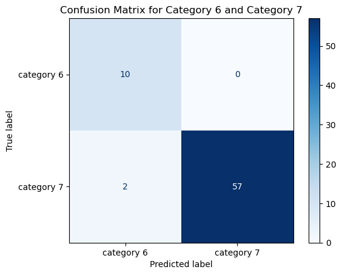

```python
from sklearn.metrics import confusion_matrix, ConfusionMatrixDisplay
import matplotlib.pyplot as plt
import numpy as np

# Predict on test data
y_test_pred = xgb_model.predict(X_test_encoded)

# Rename classes
valid_classes = [5, 6]
class_labels = {5: "category 6", 6: "category 7"}

y_test_filtered = np.array([y for y in y_test if y in valid_classes])
y_pred_filtered = np.array([y for y, true_label in zip(y_test_pred, y_test) if true_label in valid_classes])

# Compute confusion matrix for renamed classes
cm = confusion_matrix(y_test_filtered, y_pred_filtered, labels=valid_classes)

# Display confusion matrix
disp = ConfusionMatrixDisplay(confusion_matrix=cm, display_labels=[class_labels[c] for c in valid_classes])
disp.plot(cmap='Blues', values_format='d')
plt.title("Confusion Matrix for Category 6 and Category 7")
plt.show()
```

```python
# Print Dataset Shapes
print("\n🔹 Shape of Training Data:", X_train.shape)
print("🔹 Shape of Test Data:", X_test.shape)
print("🔹 Shape of Unlabeled Data:", X_unlabeled.shape)

# Print Predictions Shape
print("\n🔹 Shape of Predictions on Unlabeled Data:", y_unlabeled_pred.shape)

# Ensure Predictions Cover All Unlabeled Rows
if X_unlabeled.shape[0] == y_unlabeled_pred.shape[0]:
    print("\n✅ All unlabeled rows received predictions.")
else:
    print("\n⚠️ Mismatch in number of predictions and unlabeled samples!")
```

```
🔹 Shape of Training Data: (320, 159)
🔹 Shape of Test Data: (80, 159)
🔹 Shape of Unlabeled Data: (2891, 159)

🔹 Shape of Predictions on Unlabeled Data: (2891,)

✅ All unlabeled rows received predictions.
```

```python
# Print Class Distribution in Training Data
print("\n🔹 True Class Distribution in Training Data:")
print(pd.Series(y_train).value_counts(normalize=True) * 100)

# Print Class Distribution in Test Data
print("\n🔹 True Class Distribution in Test Data:")
print(pd.Series(y_test).value_counts(normalize=True) * 100)

# Print Class Distribution in Unlabeled Predictions
print("\n🔹 Predicted Class Distribution in Unlabeled Data:")
print(pd.Series(y_unlabeled_pred).value_counts(normalize=True) * 100)
```

```
🔹 True Class Distribution in Training Data:
Call_Type_Name
6    69.3750
5    15.3125
0     6.5625
2     4.6875
4     2.5000
1     1.2500
3     0.3125
Name: proportion, dtype: float64

🔹 True Class Distribution in Test Data:
Call_Type_Name
6    73.75
5    12.50
0    10.00
1     2.50
2     1.25
Name: proportion, dtype: float64

🔹 Predicted Class Distribution in Unlabeled Data:
0    47.838118
6    24.455206
4    19.785541
5     5.223106
1     2.663438
2     0.034590
Name: proportion, dtype: float64
```

#### Showing the actual label v/s preidcted label

```python
# Show Sample Predictions
df_comparison = pd.DataFrame({
    "Actual": label_encoder.inverse_transform(y_test),
    "Predicted": label_encoder.inverse_transform(y_test_pred)
})

# Display Random Sample
print("\n🔹 Sample Predictions vs. Actual Labels:")
print(df_comparison.sample(20))
```

```
🔹 Sample Predictions vs. Actual Labels:
        Actual   Predicted
15  Category 7  Category 7
10  Category 6  Category 6
33  Category 6  Category 6
58  Category 7  Category 7
74  Category 7  Category 7
57  Category 6  Category 6
0   Category 7  Category 7
32  Category 7  Category 7
43  Category 7  Category 7
60  Category 2  Category 2
3   Category 6  Category 6
39  Category 7  Category 7
34  Category 6  Category 6
41  Category 7  Category 7
79  Category 7  Category 7
28  Category 7  Category 7
65  Category 7  Category 7
50  Category 7  Category 6
63  Category 7  Category 7
19  Category 7  Category 6
```

```python
##### This graph presents F1-score and Recall metrics for Category 6 and Category 7
The left plot shows the F1-score and Recall for both categories.
The right plot also shows F1-score and Recall, but with slightly different values, suggesting another evaluation setting.
```

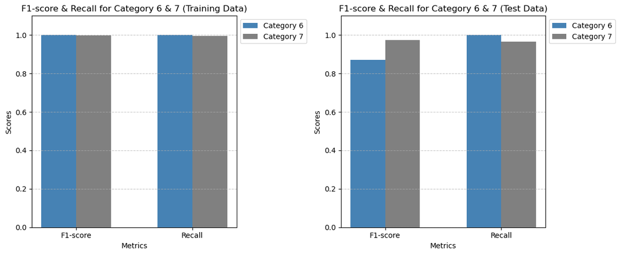

```python
import matplotlib.pyplot as plt
import numpy as np
from sklearn.metrics import classification_report

# Generate classification report as a dictionary for training data
report_train = classification_report(y_train, y_train_pred, output_dict=True)

# Extract F1-score and Recall dynamically for classes 5 & 6 from training data
class_labels = ["5", "6"]
metrics = ["f1-score", "recall"]

data_train = {label: [report_train[label][metric] for metric in metrics] for label in class_labels}

# Generate classification report as a dictionary for test data
report_test = classification_report(y_test, y_test_pred, output_dict=True)

# Extract F1-score and Recall dynamically for classes 5 & 6 from test data
data_test = {label: [report_test[label][metric] for metric in metrics] for label in class_labels}

# Convert to NumPy arrays for plotting
labels = ["F1-score", "Recall"]

category_6_values_train = np.array(data_train["5"])  # Class 5 -> Category 6 (Train)
category_7_values_train = np.array(data_train["6"])  # Class 6 -> Category 7 (Train)

category_6_values_test = np.array(data_test["5"])  # Class 5 -> Category 6 (Test)
category_7_values_test = np.array(data_test["6"])  # Class 6 -> Category 7 (Test)

x = np.arange(len(labels))  # Label locations
width = 0.3  # Bar width

# Create subplots
fig, (ax1, ax2) = plt.subplots(1, 2, figsize=(12, 5))

# Plot for Training Data
ax1.bar(x - width / 2, category_6_values_train, width, label="Category 6", color="steelblue")
ax1.bar(x + width / 2, category_7_values_train, width, label="Category 7", color="grey")
ax1.set_xlabel("Metrics")
ax1.set_ylabel("Scores")
ax1.set_title("F1-score & Recall for Category 6 & 7 (Training Data)")
ax1.set_xticks(x)
ax1.set_xticklabels(labels)
ax1.legend(loc="upper left", bbox_to_anchor=(1, 1))
ax1.set_ylim(0, 1.1)
ax1.grid(axis="y", linestyle="--", alpha=0.7)

# Plot for Test Data
ax2.bar(x - width / 2, category_6_values_test, width, label="Category 6", color="steelblue")
ax2.bar(x + width / 2, category_7_values_test, width, label="Category 7", color="grey")
ax2.set_xlabel("Metrics")
ax2.set_ylabel("Scores")
ax2.set_title("F1-score & Recall for Category 6 & 7 (Test Data)")
ax2.set_xticks(x)
ax2.set_xticklabels(labels)
ax2.legend(loc="upper left", bbox_to_anchor=(1, 1))
ax2.set_ylim(0, 1.1)
ax2.grid(axis="y", linestyle="--", alpha=0.7)

# Adjust layout to avoid overlap
plt.tight_layout()

# Show the plot
plt.show()
```